# Project 1: Calories Burned

Irina Maruna, Lucas Chapelle

2025-04-11

# 1 Introduction

This project was completed by Irina Maruna and Lucas Chapelle for DAT 402.

We use two custom datasets: **activities_dakota.csv** and **activities_lucas.csv**. These datasets contain detailed information collected from fitness trackers, covering a variety of workouts such as running, cycling, and walking. Each dataset offers rich features such as distance, duration, calories burned, heart rate metrics, and environmental conditions.

Our primary **goal** is to **predict the number of calories burned during running sessions**. We aim to identify which variables (e.g., distance, heart rate, pace) best explain calorie expenditure, using machine learning models like **Linear Regression** and **Ridge Regression**.

By combining data from two sources, this project not only increases sample size but also improves the generalizability of the analysis. The final models and results can help support personal training decisions and optimize workout strategies.

# 2 Load librarries and Import Data

## 2.1 Dakota’s dataset

```
## # A tibble: 6 × 48
##   `Activity Type` Date  Favorite Title Distance Calories Time  `Avg HR` `Max HR`
##   <chr>           <chr> <lgl>    <chr> <chr>    <chr>    <chr> <chr>    <chr>
## 1 Multisport      4/4/… FALSE    San … 17.43    862      1:21… --       195
## 2 Cycling         4/3/… FALSE    San … 9.66     361      0:41… 161      185
## 3 Running         4/1/… FALSE    San … 4.46     426      0:47… 162      196
## 4 Cycling         3/30… FALSE    San … 32.45    964      2:06… 149      182
## 5 Running         3/28… FALSE    San … 9.84     909      1:34… 162      188
## 6 Running         3/27… FALSE    San … 2.06     192      0:17… 181      188
## # ℹ 39 more variables: `Aerobic TE` <chr>, `Avg Bike Cadence` <chr>,
## #   `Max Bike Cadence` <chr>, `Avg Speed` <chr>, `Max Speed` <chr>,
## #   `Total Ascent` <chr>, `Total Descent` <chr>, `Avg Stride Length` <chr>,
## #   `Avg Vertical Ratio` <chr>, `Avg Vertical Oscillation` <chr>,
## #   `Avg Ground Contact Time` <chr>, `Avg GAP` <chr>,
## #   `Normalized Power® (NP®)` <chr>, `Training Stress Score®` <dbl>,
## #   `Avg Power` <chr>, `Max Power` <chr>, `Total Strokes` <chr>, …
```

*This dataset includes Dakota’s tracked fitness activities such as running, cycling, and swimming. It contains 48 columns, including distance, time, calories, and heart rate metrics. We’ll filter for running activities and use key features like distance and heart rate for calorie prediction.*

## 2.2 Lukas’s dataset

```
## ──────────────────────────────────────────────────────── Delimiter: "," chr
## (7): Activity Date, Activity Name, Activity Type, Activity Description,... dbl
## (64): Activity ID, Elapsed Time...6, Max Heart Rate...8, Relative Effort... num
## (1): Distance...7 lgl (22): Commute...10, Activity Private Note, Athlete
## Weight, Average Posit...
```

```
## # A tibble: 6 × 94
##   `Activity ID` `Activity Date`           `Activity Name` `Activity Type`
##           <dbl> <chr>                     <chr>           <chr>
## 1   11503217819 May 26, 2024, 3:05:53 PM  Morning Walk    Walk
## 2   11504286868 May 26, 2024, 5:06:38 PM  Morning Walk    Walk
## 3   11505881808 May 26, 2024, 10:56:52 PM Afternoon Walk  Walk
## 4   11513410460 May 28, 2024, 12:32:58 AM Afternoon Walk  Walk
## 5   11518416937 May 28, 2024, 4:52:17 PM  Morning Walk    Walk
## 6   11526239058 May 29, 2024, 4:13:16 PM  Morning Walk    Walk
## # ℹ 90 more variables: `Activity Description` <chr>, `Elapsed Time...6` <dbl>,
## #   Distance...7 <dbl>, `Max Heart Rate...8` <dbl>,
## #   `Relative Effort...9` <dbl>, Commute...10 <lgl>,
## #   `Activity Private Note` <lgl>, `Activity Gear` <chr>, Filename <chr>,
## #   `Athlete Weight` <lgl>, `Bike Weight` <dbl>, `Elapsed Time...16` <dbl>,
## #   `Moving Time` <dbl>, Distance...18 <dbl>, `Max Speed` <dbl>,
## #   `Average Speed` <dbl>, `Elevation Gain` <dbl>, `Elevation Loss` <dbl>, …
```

*Lucas’ dataset contains 94 columns with detailed activity, environmental, and physiological data. It includes fields like heart rate, temperature, elevation gain, and more. We will explore this dataset to either combine relevant parts with Dakota’s or use it as a separate model extension.*

# 3 Data overview and Filtering

```r
# Structure and column names
glimpse(dakota_data)
```

```
## Rows: 274
## Columns: 48
## $ `Activity Type`            <chr> "Multisport", "Cycling", "Running", "Cyclin…
## $ Date                       <chr> "4/4/25 11:29", "4/3/25 14:13", "4/1/25 18:…
## $ Favorite                   <lgl> FALSE, FALSE, FALSE, FALSE, FALSE, FALSE, F…
## $ Title                      <chr> "San Diego Multisport", "San Diego Cycling"…
## $ Distance                   <chr> "17.43", "9.66", "4.46", "32.45", "9.84", "…
## $ Calories                   <chr> "862", "361", "426", "964", "909", "192", "…
## $ Time                       <chr> "1:21:09", "0:41:20", "0:47:36", "2:06:59",…
## $ `Avg HR`                   <chr> "--", "161", "162", "149", "162", "181", "1…
## $ `Max HR`                   <chr> "195", "185", "196", "182", "188", "188", "…
## $ `Aerobic TE`               <chr> "4.8", "3.3", "3.4", "3.5", "4.1", "3.1", "…
## $ `Avg Bike Cadence`         <chr> "--", "--", "144", "--", "155", "165", "--"…
## $ `Max Bike Cadence`         <chr> "--", "--", "239", "--", "211", "174", "--"…
## $ `Avg Speed`                <chr> "12.9", "14", "10:40", "15.3", "9:34", "8:2…
```

[output cut: 35 more lines]

```r
glimpse(lucas_data)
```

```
## Rows: 226
## Columns: 94
## $ `Activity ID`                  <dbl> 11503217819, 11504286868, 11505881808, …
## $ `Activity Date`                <chr> "May 26, 2024, 3:05:53 PM", "May 26, 20…
## $ `Activity Name`                <chr> "Morning Walk", "Morning Walk", "Aftern…
## $ `Activity Type`                <chr> "Walk", "Walk", "Walk", "Walk", "Walk",…
## $ `Activity Description`         <chr> NA, NA, NA, NA, NA, NA, NA, NA, NA, NA,…
## $ `Elapsed Time...6`             <dbl> 1836, 1661, 374, 1858, 2202, 3282, 2284…
## $ Distance...7                   <dbl> 3.09, 3.79, 0.68, 3.39, 4.59, 3.51, 2.1…
## $ `Max Heart Rate...8`           <dbl> NA, NA, NA, NA, NA, NA, NA, NA, NA, NA,…
## $ `Relative Effort...9`          <dbl> NA, NA, NA, NA, NA, NA, NA, NA, NA, NA,…
## $ Commute...10                   <lgl> FALSE, FALSE, FALSE, FALSE, FALSE, FALS…
## $ `Activity Private Note`        <lgl> NA, NA, NA, NA, NA, NA, NA, NA, NA, NA,…
## $ `Activity Gear`                <chr> NA, NA, NA, NA, NA, NA, NA, NA, NA, NA,…
## $ Filename                       <chr> "activities/11503217819.gpx", "activiti…
```

[output cut: 81 more lines]

```r
# Filter only "Running" activities
dakota_run <- dakota_data %>%
  filter(tolower(trimws(`Activity Type`)) == "running")

lucas_run <- lucas_data %>%
  filter(tolower(trimws(`Activity Type`)) == "run")  # check this spelling in lucas_data!

# Check how many runs
cat("Dakota running activities:", nrow(dakota_run), "\n")
```

```
## Dakota running activities: 71
```

```r
cat("Lucas running activities:", nrow(lucas_run), "\n")
```

```
## Lucas running activities: 108
```

```r
# Preview filtered data
head(dakota_run)
```

```
## # A tibble: 6 × 48
##   `Activity Type` Date  Favorite Title Distance Calories Time  `Avg HR` `Max HR`
##   <chr>           <chr> <lgl>    <chr> <chr>    <chr>    <chr> <chr>    <chr>
## 1 Running         4/1/… FALSE    San … 4.46     426      0:47… 162      196
## 2 Running         3/28… FALSE    San … 9.84     909      1:34… 162      188
## 3 Running         3/27… FALSE    San … 2.06     192      0:17… 181      188
## 4 Running         3/26… FALSE    San … 2.03     174      0:17… 169      192
## 5 Running         3/24… FALSE    San … 6.04     551      0:55… 166      187
## 6 Running         3/18… FALSE    San … 4.22     385      0:39… 163      186
## # ℹ 39 more variables: `Aerobic TE` <chr>, `Avg Bike Cadence` <chr>,
## #   `Max Bike Cadence` <chr>, `Avg Speed` <chr>, `Max Speed` <chr>,
## #   `Total Ascent` <chr>, `Total Descent` <chr>, `Avg Stride Length` <chr>,
## #   `Avg Vertical Ratio` <chr>, `Avg Vertical Oscillation` <chr>,
## #   `Avg Ground Contact Time` <chr>, `Avg GAP` <chr>,
## #   `Normalized Power® (NP®)` <chr>, `Training Stress Score®` <dbl>,
## #   `Avg Power` <chr>, `Max Power` <chr>, `Total Strokes` <chr>, …
```

```r
head(lucas_run)
```

```
## # A tibble: 6 × 94
##   `Activity ID` `Activity Date`          `Activity Name` `Activity Type`
##           <dbl> <chr>                    <chr>           <chr>
## 1   11559007912 Jun 2, 2024, 8:03:19 PM  Afternoon Run   Run
## 2   11559044844 Jun 2, 2024, 8:08:53 PM  Afternoon Run   Run
## 3   11559101006 Jun 2, 2024, 8:20:09 PM  Afternoon Run   Run
## 4   11592288878 Jun 7, 2024, 12:31:23 AM Afternoon Run   Run
## 5   11616151803 Jun 10, 2024, 1:27:42 AM Evening Run     Run
## 6   11628142904 Jun 11, 2024, 4:09:17 PM Morning Run     Run
## # ℹ 90 more variables: `Activity Description` <chr>, `Elapsed Time...6` <dbl>,
## #   Distance...7 <dbl>, `Max Heart Rate...8` <dbl>,
## #   `Relative Effort...9` <dbl>, Commute...10 <lgl>,
## #   `Activity Private Note` <lgl>, `Activity Gear` <chr>, Filename <chr>,
## #   `Athlete Weight` <lgl>, `Bike Weight` <dbl>, `Elapsed Time...16` <dbl>,
## #   `Moving Time` <dbl>, Distance...18 <dbl>, `Max Speed` <dbl>,
## #   `Average Speed` <dbl>, `Elevation Gain` <dbl>, `Elevation Loss` <dbl>, …
```

# 4 Data Cleaning & Feature Selection

## 4.1 Cleaning Dakota’s dataset

```r
dakota_run$Calories <- gsub("[^0-9.]", "", dakota_run$Calories)
# Convert relevant columns to numeric
dakota_clean <- dakota_run %>%
  mutate(
    Distance = as.numeric(Distance),
    Calories = as.numeric(Calories),
    Avg_HR = as.numeric(`Avg HR`),
    Max_HR = as.numeric(`Max HR`)
  )

# Convert Time to total minutes
convert_to_minutes <- function(time_str) {
  parts <- strsplit(time_str, ":")[[1]]
  if (length(parts) == 3) {
    return(as.numeric(parts[1]) * 60 + as.numeric(parts[2]) + as.numeric(parts[3]) / 60)
  } else {
    return(NA)
  }
}

dakota_clean$Time_Minutes <- sapply(dakota_clean$Time, convert_to_minutes)

# Select only needed columns
dakota_clean <- dakota_clean %>%
  select(Distance, Calories, Avg_HR, Max_HR, Time_Minutes) %>%
  mutate(Source = "Dakota")

# Create Pace (min per km)
dakota_clean <- dakota_clean %>%
  mutate(Pace = Time_Minutes / Distance)

# Remove rows with missing values
dakota_clean <- na.omit(dakota_clean)

# Preview cleaned result
head(dakota_clean)
```

```
## # A tibble: 6 × 7
##   Distance Calories Avg_HR Max_HR Time_Minutes Source  Pace
##      <dbl>    <dbl>  <dbl>  <dbl>        <dbl> <chr>  <dbl>
## 1     4.46      426    162    196         47.6 Dakota 10.7
## 2     9.84      909    162    188         94.1 Dakota  9.57
## 3     2.06      192    181    188         17.5 Dakota  8.50
## 4     2.03      174    169    192         17.1 Dakota  8.41
## 5     6.04      551    166    187         55.1 Dakota  9.12
## 6     4.22      385    163    186         39.6 Dakota  9.39
```

```r
summary(dakota_clean)
```

```
##     Distance         Calories          Avg_HR          Max_HR
##  Min.   : 0.520   Min.   : 108.0   Min.   : 97.0   Min.   :147.0
##  1st Qu.: 1.860   1st Qu.: 195.0   1st Qu.:148.0   1st Qu.:182.0
##  Median : 3.030   Median : 282.0   Median :162.0   Median :188.0
##  Mean   : 3.311   Mean   : 324.2   Mean   :158.3   Mean   :185.9
##  3rd Qu.: 4.270   3rd Qu.: 406.0   3rd Qu.:172.0   3rd Qu.:193.0
##  Max.   :13.150   Max.   :1332.0   Max.   :189.0   Max.   :205.0
##   Time_Minutes       Source               Pace
##  Min.   : 14.63   Length:69          Min.   : 8.045
##  1st Qu.: 22.28   Class :character   1st Qu.: 9.479
##  Median : 32.85   Mode  :character   Median :10.352
##  Mean   : 36.86                      Mean   :12.133
##  3rd Qu.: 44.40                      3rd Qu.:11.979
##  Max.   :114.40                      Max.   :31.480
```

## 4.2 Cleaning Lukas’s dataset

```r
# Convert relevant columns using actual column names
lucas_clean <- lucas_run %>%
  mutate(
    Distance = as.numeric(`Distance...7`),
    Calories = as.numeric(Calories),
    Avg_HR = as.numeric(`Average Heart Rate`),
    Max_HR = as.numeric(`Max Heart Rate...8`),
    Time = as.numeric(`Elapsed Time...6`)  # elapsed time in seconds
  )

# Convert seconds to minutes
lucas_clean$Time_Minutes <- lucas_clean$Time / 60

# Select only needed columns
lucas_clean <- lucas_clean %>%
  select(Distance, Calories, Avg_HR, Max_HR, Time_Minutes) %>%
  mutate(Source = "Lucas")

# Create Pace (min/km)
lucas_clean <- lucas_clean %>%
  mutate(Pace = Time_Minutes / Distance)

# Remove rows with missing values
lucas_clean <- na.omit(lucas_clean)

# Preview cleaned data
head(lucas_clean)
```

```
## # A tibble: 6 × 7
##   Distance Calories Avg_HR Max_HR Time_Minutes Source  Pace
##      <dbl>    <dbl>  <dbl>  <dbl>        <dbl> <chr>  <dbl>
## 1     5.38     513.   157.    187         28.9 Lucas   5.37
## 2     5.04     485.   173.    188         25.8 Lucas   5.12
## 3     8.06     777.   167.    182         46.0 Lucas   5.71
## 4     7.69     731.   166.    188         44.8 Lucas   5.83
## 5     8.07     777.   172.    189         39.6 Lucas   4.90
## 6     5.09     487.   174.    187         21.8 Lucas   4.28
```

```r
summary(lucas_clean)
```

```
##     Distance         Calories          Avg_HR          Max_HR
##  Min.   : 0.580   Min.   :  23.0   Min.   :140.7   Min.   :154.0
##  1st Qu.: 5.143   1st Qu.: 313.8   1st Qu.:154.2   1st Qu.:176.8
##  Median : 7.680   Median : 484.1   Median :161.4   Median :183.5
##  Mean   : 8.540   Mean   : 572.5   Mean   :161.3   Mean   :180.9
##  3rd Qu.:10.152   3rd Qu.: 778.8   3rd Qu.:169.6   3rd Qu.:187.0
##  Max.   :21.410   Max.   :2039.3   Max.   :189.8   Max.   :211.0
##   Time_Minutes        Source               Pace
##  Min.   :  2.117   Length:64          Min.   : 3.515
##  1st Qu.: 25.871   Class :character   1st Qu.: 4.575
##  Median : 38.983   Mode  :character   Median : 5.131
##  Mean   : 48.736                      Mean   : 6.097
##  3rd Qu.: 54.479                      3rd Qu.: 5.633
##  Max.   :275.867                      Max.   :69.313
```

## 4.3 Combine datasets

```r
# Combine Dakota's and Lucas's cleaned datasets
combined_data <- bind_rows(dakota_clean, lucas_clean)

# Preview combined dataset
head(combined_data)
```

```
## # A tibble: 6 × 7
##   Distance Calories Avg_HR Max_HR Time_Minutes Source  Pace
##      <dbl>    <dbl>  <dbl>  <dbl>        <dbl> <chr>  <dbl>
## 1     4.46      426    162    196         47.6 Dakota 10.7
## 2     9.84      909    162    188         94.1 Dakota  9.57
## 3     2.06      192    181    188         17.5 Dakota  8.50
## 4     2.03      174    169    192         17.1 Dakota  8.41
## 5     6.04      551    166    187         55.1 Dakota  9.12
## 6     4.22      385    163    186         39.6 Dakota  9.39
```

```r
summary(combined_data)
```

```
##     Distance         Calories          Avg_HR          Max_HR
##  Min.   : 0.520   Min.   :  23.0   Min.   : 97.0   Min.   :147.0
##  1st Qu.: 2.370   1st Qu.: 217.0   1st Qu.:151.0   1st Qu.:179.0
##  Median : 4.610   Median : 363.0   Median :162.0   Median :185.0
##  Mean   : 5.827   Mean   : 443.7   Mean   :159.8   Mean   :183.5
##  3rd Qu.: 7.690   3rd Qu.: 519.0   3rd Qu.:171.0   3rd Qu.:190.0
##  Max.   :21.410   Max.   :2039.3   Max.   :189.8   Max.   :211.0
##   Time_Minutes        Source               Pace
##  Min.   :  2.117   Length:133         Min.   : 3.515
##  1st Qu.: 24.217   Class :character   1st Qu.: 5.219
##  Median : 35.300   Mode  :character   Median : 8.503
##  Mean   : 42.574                      Mean   : 9.229
##  3rd Qu.: 48.017                      3rd Qu.:10.483
##  Max.   :275.867                      Max.   :69.313
```

# 5 Exploratory Data Analysis (EDA)

## 5.1 Summary and structure

```r
# Summary statistics and structure
summary(combined_data)
```

```
##     Distance         Calories          Avg_HR          Max_HR
##  Min.   : 0.520   Min.   :  23.0   Min.   : 97.0   Min.   :147.0
##  1st Qu.: 2.370   1st Qu.: 217.0   1st Qu.:151.0   1st Qu.:179.0
##  Median : 4.610   Median : 363.0   Median :162.0   Median :185.0
##  Mean   : 5.827   Mean   : 443.7   Mean   :159.8   Mean   :183.5
##  3rd Qu.: 7.690   3rd Qu.: 519.0   3rd Qu.:171.0   3rd Qu.:190.0
##  Max.   :21.410   Max.   :2039.3   Max.   :189.8   Max.   :211.0
##   Time_Minutes        Source               Pace
##  Min.   :  2.117   Length:133         Min.   : 3.515
##  1st Qu.: 24.217   Class :character   1st Qu.: 5.219
##  Median : 35.300   Mode  :character   Median : 8.503
##  Mean   : 42.574                      Mean   : 9.229
##  3rd Qu.: 48.017                      3rd Qu.:10.483
##  Max.   :275.867                      Max.   :69.313
```

```r
glimpse(combined_data)
```

```
## Rows: 133
## Columns: 7
## $ Distance     <dbl> 4.46, 9.84, 2.06, 2.03, 6.04, 4.22, 4.27, 5.07, 4.94, 3.2…
## $ Calories     <dbl> 426, 909, 192, 174, 551, 385, 416, 490, 490, 306, 282, 45…
## $ Avg_HR       <dbl> 162, 162, 181, 169, 166, 163, 184, 176, 174, 171, 178, 17…
## $ Max_HR       <dbl> 196, 188, 188, 192, 187, 186, 194, 191, 192, 192, 192, 18…
## $ Time_Minutes <dbl> 47.60000, 94.13333, 17.51667, 17.06667, 55.08333, 39.6166…
## $ Source       <chr> "Dakota", "Dakota", "Dakota", "Dakota", "Dakota", "Dakota…
## $ Pace         <dbl> 10.672646, 9.566396, 8.503236, 8.407225, 9.119757, 9.3878…
```

## 5.2 Histogramms

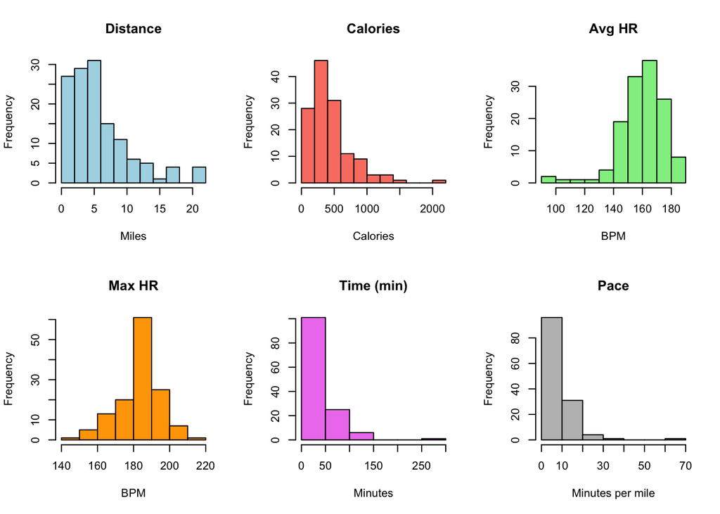

```r
par(mfrow = c(2, 3))  # Arrange plots in 2 rows, 3 columns

hist(combined_data$Distance, main = "Distance", col = "lightblue", xlab = "Miles")
hist(combined_data$Calories, main = "Calories", col = "salmon", xlab = "Calories")
hist(combined_data$Avg_HR, main = "Avg HR", col = "lightgreen", xlab = "BPM")
hist(combined_data$Max_HR, main = "Max HR", col = "orange", xlab = "BPM")
hist(combined_data$Time_Minutes, main = "Time (min)", col = "violet", xlab = "Minutes")
hist(combined_data$Pace, main = "Pace", col = "gray", xlab = "Minutes per mile")
```

```r
par(mfrow = c(1,1))  # Reset
```

- *The histograms show that most runs are shorter than 10 miles, with calories burned commonly under 1000.*
- *Avg and Max Heart Rate are roughly normal, slightly left-skewed.*
- *Time and Pace are strongly right-skewed due to a few very long or slow runs.*

## 5.3 Plots

```r
cor(combined_data[, c("Distance", "Calories", "Avg_HR", "Max_HR", "Time_Minutes", "Pace")])
```

```
##                 Distance    Calories      Avg_HR      Max_HR Time_Minutes
## Distance      1.00000000  0.89742874  0.17063821 -0.03223527   0.62842023
## Calories      0.89742874  1.00000000  0.21597656  0.07819275   0.61396187
## Avg_HR        0.17063821  0.21597656  1.00000000  0.64073652  -0.08896117
## Max_HR       -0.03223527  0.07819275  0.64073652  1.00000000  -0.12497792
## Time_Minutes  0.62842023  0.61396187 -0.08896117 -0.12497792   1.00000000
## Pace         -0.33404505 -0.26895753 -0.46778533 -0.15318286   0.43680575
##                    Pace
## Distance     -0.3340450
## Calories     -0.2689575
## Avg_HR       -0.4677853
## Max_HR       -0.1531829
## Time_Minutes  0.4368058
## Pace          1.0000000
```

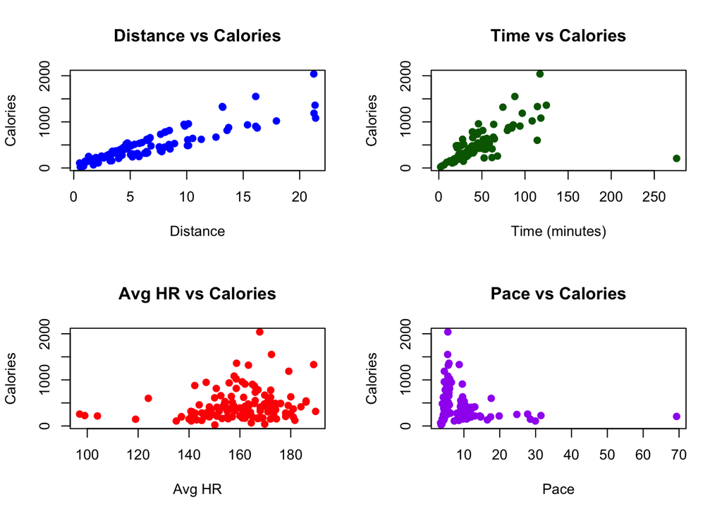

```r
par(mfrow = c(2, 2))
plot(combined_data$Distance, combined_data$Calories,
     main = "Distance vs Calories", xlab = "Distance", ylab = "Calories", col = "blue", pch = 19)

plot(combined_data$Time_Minutes, combined_data$Calories,
     main = "Time vs Calories", xlab = "Time (minutes)", ylab = "Calories", col = "darkgreen", pch = 19)

plot(combined_data$Avg_HR, combined_data$Calories,
     main = "Avg HR vs Calories", xlab = "Avg HR", ylab = "Calories", col = "red", pch = 19)

plot(combined_data$Pace, combined_data$Calories,
     main = "Pace vs Calories", xlab = "Pace", ylab = "Calories", col = "purple", pch = 19)
```

```r
par(mfrow = c(1,1))
```

# 6 Model Building – Linear Regression

```r
set.seed(42)  # for reproducibility

# Train-test split (70% train, 30% test)
sample_index <- sample(1:nrow(combined_data), size = 0.7 * nrow(combined_data))
train_data <- combined_data[sample_index, ]
test_data  <- combined_data[-sample_index, ]

# Build linear regression model
model_lm <- lm(Calories ~ Distance + Avg_HR + Max_HR + Time_Minutes + Pace, data = train_data)

# View model summary
summary(model_lm)
```

```
##
## Call:
## lm(formula = Calories ~ Distance + Avg_HR + Max_HR + Time_Minutes +
##     Pace, data = train_data)
##
## Residuals:
##     Min      1Q  Median      3Q     Max
## -215.05  -95.75    2.17   60.48  633.42
##
## Coefficients:
##               Estimate Std. Error t value Pr(>|t|)
## (Intercept)  -382.2261   231.9041  -1.648   0.1029
## Distance       49.5536     8.0685   6.142 2.38e-08 ***
## Avg_HR         -0.8636     1.5332  -0.563   0.5747
## Max_HR          3.4857     1.7547   1.986   0.0501 .
## Time_Minutes    2.4413     1.2109   2.016   0.0469 *
## Pace           -7.4086     4.9131  -1.508   0.1352
## ---
## Signif. codes:  0 '***' 0.001 '**' 0.01 '*' 0.05 '.' 0.1 ' ' 1
##
## Residual standard error: 137.6 on 87 degrees of freedom
## Multiple R-squared:  0.8184, Adjusted R-squared:  0.8079
## F-statistic: 78.39 on 5 and 87 DF,  p-value: < 2.2e-16
```

*We built a linear regression model to predict Calories burned using Distance, Avg HR, Max HR, Time (min), and Pace.*

**Model Performance**:

- R-squared = 0.818. The model explains about 82% of the variance in calories burned, showing a strong fit.
- Residuals: The median residual is low (~2.17), with some larger values, suggesting a few outliers.

**Key Insights**:

- Distance is the most important and statistically significant predictor (p < 0.001). Longer runs burn more calories.
- Time_Minutes is also significant (p < 0.05), meaning longer duration is a strong calorie predictor.
- Max_HR is borderline significant (p ia round 0.05), indicating a possible small effect.
- Avg_HR and Pace are not statistically significant in this model, likely due to collinearity with other variables.

**Conclusion**: Distance and Time are the most reliable features for predicting calorie burn during runs.

# 7 Ridge Regression

```r
# Load necessary library
library(glmnet)
# Prepare data for glmnet (matrices required)
x_train <- as.matrix(train_data[, c("Distance", "Avg_HR", "Max_HR", "Time_Minutes", "Pace")])
y_train <- train_data$Calories

x_test <- as.matrix(test_data[, c("Distance", "Avg_HR", "Max_HR", "Time_Minutes", "Pace")])
y_test <- test_data$Calories

# Ridge regression with cross-validation to choose lambda
set.seed(42)
ridge_cv <- cv.glmnet(x_train, y_train, alpha = 0)

# Optimal lambda
best_lambda <- ridge_cv$lambda.min

# Final model
ridge_model <- glmnet(x_train, y_train, alpha = 0, lambda = best_lambda)

# Predict
ridge_preds <- predict(ridge_model, s = best_lambda, newx = x_test)

# R-squared and RMSE
ridge_r2 <- 1 - sum((y_test - ridge_preds)^2) / sum((y_test - mean(y_test))^2)
ridge_rmse <- sqrt(mean((y_test - ridge_preds)^2))

ridge_r2
```

```
## [1] 0.8180744
```

```r
ridge_rmse
```

```
## [1] 144.8884
```

To evaluate the Ridge Regression model, we used two key performance metrics:

*This may be because the dataset is already relatively clean and well-structured, and the additional regularization from Ridge did not provide extra benefit. Still, testing Ridge regression is useful for model comparison and reinforces the reliability of the linear model’s results.*

# 8 Model Evaluation – Ridge Regression

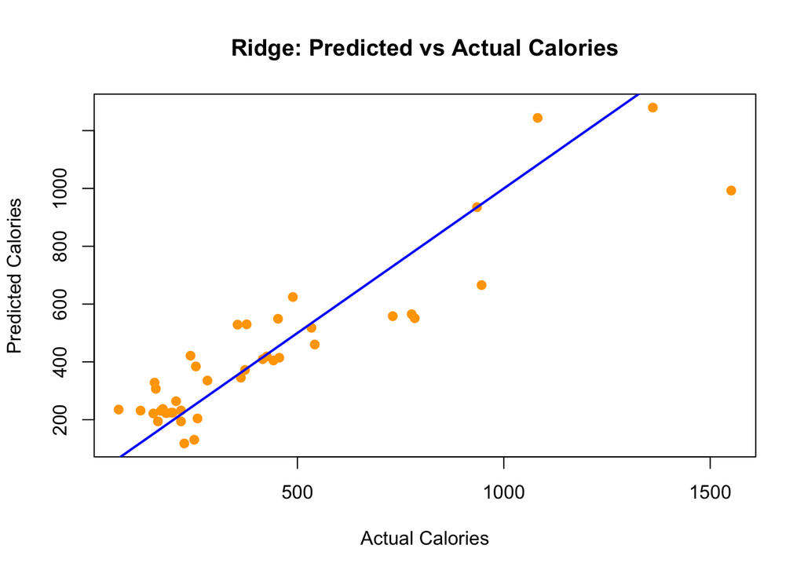

```r
# Plot: Predicted vs Actual Calories
plot(y_test, ridge_preds,
     main = "Ridge: Predicted vs Actual Calories",
     xlab = "Actual Calories", ylab = "Predicted Calories",
     pch = 19, col = "orange")
abline(0, 1, col = "blue", lwd = 2)  # reference line
```

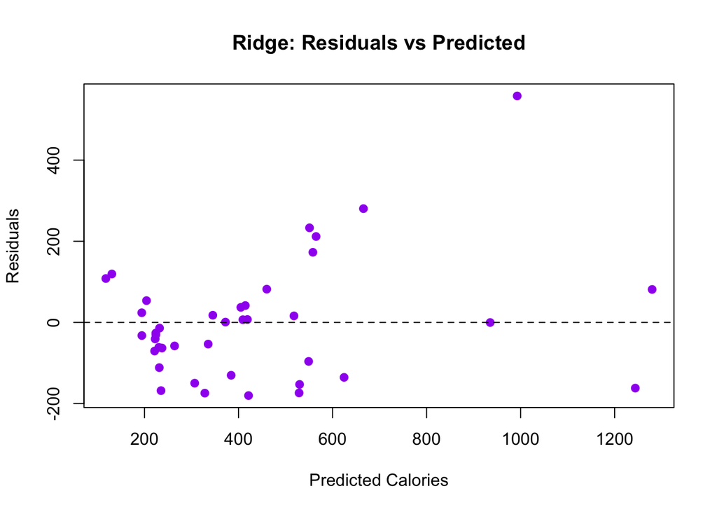

```r
# Plot: Residuals vs Predicted
residuals <- y_test - ridge_preds
plot(ridge_preds, residuals,
     main = "Ridge: Residuals vs Predicted",
     xlab = "Predicted Calories", ylab = "Residuals",
     pch = 19, col = "purple")
abline(h = 0, lty = 2)
```

We also used two visualizations to assess model performance:

- **Predicted vs Actual Calories**: *The plot shows that most predictions fall near the reference line, suggesting the model captures general calorie patterns reasonably well. However, some under- and over-prediction is visible, especially for higher calorie values.*
- **Residuals vs Predicted Calories**: *The plot reveals a wider spread of residuals at higher predicted values, and some systematic variation, indicating the model may not fully capture all underlying patterns. This supports the slightly lower performance metrics we saw earlier (R²=0.818, RMSE is around 145), and suggests that while the Ridge model performs decently, it doesn’t improve much over standard linear regression.*

# 9 Cross-Validation with Ridge Regression

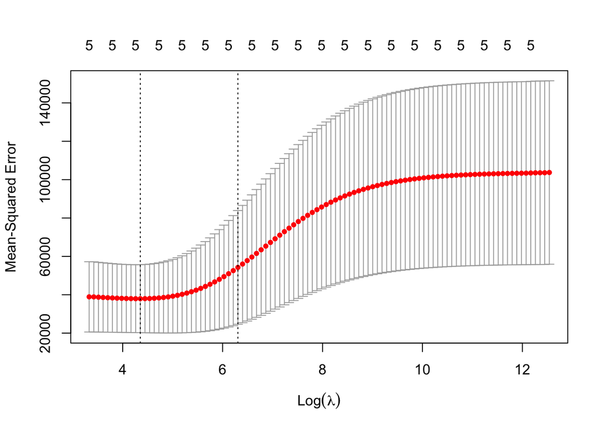

```r
# Load required package
library(glmnet)

# Prepare data from the combined and cleaned training set
x <- as.matrix(train_data[, c("Distance", "Avg_HR", "Max_HR", "Time_Minutes", "Pace")])
y <- train_data$Calories

# Perform 10-fold cross-validation for Ridge Regression
set.seed(42)
cv_ridge <- cv.glmnet(x, y, alpha = 0, nfolds = 10)

# Plot cross-validation error vs. lambda
plot(cv_ridge)
```

```r
# Extract the best lambda
best_lambda <- cv_ridge$lambda.min
best_lambda
```

```
## [1] 77.66514
```

# 10 Conclusion